# Meta-analysis of genes [DRAFT]

## MA_20211008_ALL

```r
library(dplyr)
library(knitr)
load("MA_20211008_ALL.RData")
```

### Significant results

```r
kable(sig.genes.df[,1:11], caption='Statistics of 27 significant genes')
```

Statistics of 27 significant genes

|  | lower_bound | logFC | upper_bound | pvalue | QE | QEp | SE | tau2 | I2 | H2 | p.adjust.fdr |
| --- | --- | --- | --- | --- | --- | --- | --- | --- | --- | --- | --- |
| CNDP2 | 0.046 | 0.069 | 0.091 | 0 | 6.640 | 0.675 | 0.012 | 0.000 | 0.000 | 1.000 | 0.000 |
| UBIAD1 | 0.036 | 0.056 | 0.075 | 0 | 5.851 | 0.828 | 0.010 | 0.000 | 0.000 | 1.000 | 0.000 |
| LINC01362 | -0.235 | -0.170 | -0.105 | 0 | 0.859 | 0.354 | 0.033 | 0.000 | 0.000 | 1.000 | 0.002 |
| SLC29A1 | -0.182 | -0.132 | -0.081 | 0 | 5.631 | 0.688 | 0.026 | 0.000 | 0.000 | 1.000 | 0.002 |
| COMMD2 | 0.077 | 0.127 | 0.177 | 0 | 10.095 | 0.343 | 0.026 | 0.001 | 10.849 | 1.122 | 0.004 |
| ATP6V0D2 | -0.517 | -0.368 | -0.219 | 0 | 3.242 | 0.518 | 0.076 | 0.000 | 0.000 | 1.000 | 0.006 |
| LOC91561 | 0.024 | 0.041 | 0.058 | 0 | 1.083 | 0.781 | 0.009 | 0.000 | 0.000 | 1.000 | 0.007 |
| SECTM1 | -0.418 | -0.296 | -0.174 | 0 | 3.217 | 0.864 | 0.062 | 0.000 | 0.000 | 1.000 | 0.007 |
| TMED1 | 0.032 | 0.056 | 0.080 | 0 | 2.864 | 0.969 | 0.012 | 0.000 | 0.000 | 1.000 | 0.010 |
| LOC400566 | -0.183 | -0.128 | -0.073 | 0 | 0.974 | 0.614 | 0.028 | 0.000 | 0.000 | 1.000 | 0.011 |
| PFKP | -0.129 | -0.090 | -0.051 | 0 | 6.922 | 0.437 | 0.020 | 0.000 | 0.000 | 1.000 | 0.011 |
| TSPAN33 | 0.049 | 0.086 | 0.122 | 0 | 6.303 | 0.789 | 0.019 | 0.000 | 0.000 | 1.000 | 0.011 |
| ZFR | 0.029 | 0.051 | 0.073 | 0 | 4.322 | 0.932 | 0.011 | 0.000 | 0.000 | 1.000 | 0.012 |
| DFFA | 0.062 | 0.110 | 0.158 | 0 | 7.198 | 0.515 | 0.025 | 0.000 | 0.000 | 1.000 | 0.013 |
| TCEA3 | 0.075 | 0.136 | 0.196 | 0 | 4.879 | 0.770 | 0.031 | 0.000 | 0.000 | 1.000 | 0.018 |
| AMTN | -0.434 | -0.300 | -0.165 | 0 | 1.401 | 0.705 | 0.069 | 0.000 | 0.000 | 1.000 | 0.020 |
| FAM205B | -0.173 | -0.118 | -0.064 | 0 | 0.076 | 0.783 | 0.028 | 0.000 | 0.000 | 1.000 | 0.026 |
| RYBP | 0.055 | 0.101 | 0.148 | 0 | 8.121 | 0.617 | 0.024 | 0.000 | 0.000 | 1.000 | 0.026 |
| BSCL2 | -0.064 | -0.044 | -0.023 | 0 | 2.847 | 0.944 | 0.010 | 0.000 | 0.000 | 1.000 | 0.029 |
| FCGBP | 0.156 | 0.290 | 0.424 | 0 | 11.497 | 0.243 | 0.068 | 0.009 | 21.716 | 1.277 | 0.030 |
| LRRCC1 | 0.054 | 0.100 | 0.147 | 0 | 5.704 | 0.839 | 0.024 | 0.000 | 0.000 | 1.000 | 0.031 |
| MLEC | 0.134 | 0.253 | 0.372 | 0 | 1.782 | 0.939 | 0.061 | 0.000 | 0.000 | 1.000 | 0.033 |
| PIB5PA | -0.147 | -0.100 | -0.053 | 0 | 2.354 | 0.502 | 0.024 | 0.000 | 0.000 | 1.000 | 0.033 |
| ISOC2 | 0.037 | 0.070 | 0.104 | 0 | 6.712 | 0.568 | 0.017 | 0.000 | 0.000 | 1.000 | 0.035 |
| SMARCA5 | 0.036 | 0.069 | 0.101 | 0 | 6.470 | 0.595 | 0.017 | 0.000 | 0.000 | 1.000 | 0.036 |
| TMCC1 | -0.135 | -0.091 | -0.048 | 0 | 11.711 | 0.305 | 0.022 | 0.001 | 14.610 | 1.171 | 0.036 |
| USP46 | 0.032 | 0.060 | 0.089 | 0 | 4.404 | 0.883 | 0.015 | 0.000 | 0.000 | 1.000 | 0.038 |

### CNDP2

**Statistics of CNDP2 meta-analisys**

```r
kable(sig.genes.df['CNDP2',1:11])
```

|  | lower_bound | logFC | upper_bound | pvalue | QE | QEp | SE | tau2 | I2 | H2 | p.adjust.fdr |
| --- | --- | --- | --- | --- | --- | --- | --- | --- | --- | --- | --- |
| CNDP2 | 0.046 | 0.069 | 0.091 | 0 | 6.64 | 0.675 | 0.012 | 0 | 0 | 1 | 0 |

[Gene information](https://www.genecards.org/cgi-bin/carddisp.pl?gene=CNDP2)

**Forest plot**

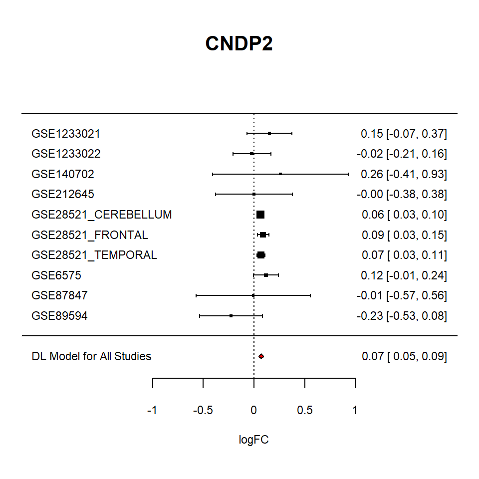

```r
knitr::include_graphics("plots/CNDP2_FOREST.png")
```

**Funnel plot**

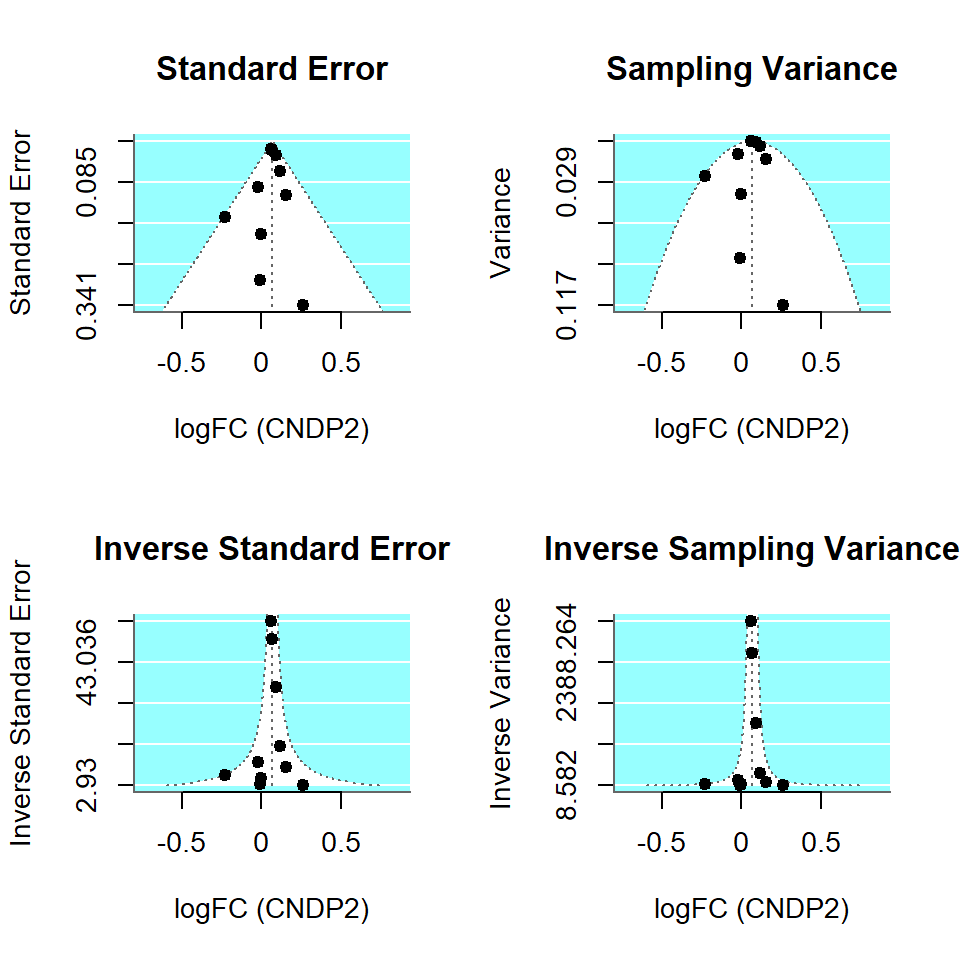

```r
knitr::include_graphics("plots/CNDP2_FUNNEL.png")
```

**Incluence plot**

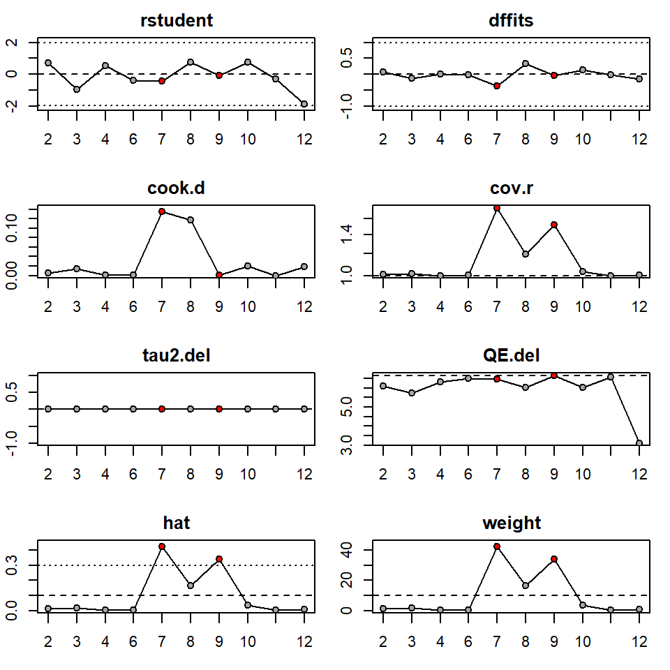

```r
knitr::include_graphics("plots/CNDP2_INFLUENCE.png")
```

### UBIAD1

**Statistics of UBIAD1 meta-analisys**

```r
kable(sig.genes.df['UBIAD1',1:11])
```

|  | lower_bound | logFC | upper_bound | pvalue | QE | QEp | SE | tau2 | I2 | H2 | p.adjust.fdr |
| --- | --- | --- | --- | --- | --- | --- | --- | --- | --- | --- | --- |
| UBIAD1 | 0.036 | 0.056 | 0.075 | 0 | 5.851 | 0.828 | 0.01 | 0 | 0 | 1 | 0 |

[Gene information](https://www.genecards.org/cgi-bin/carddisp.pl?gene=UBIAD1)

**Forest plot**

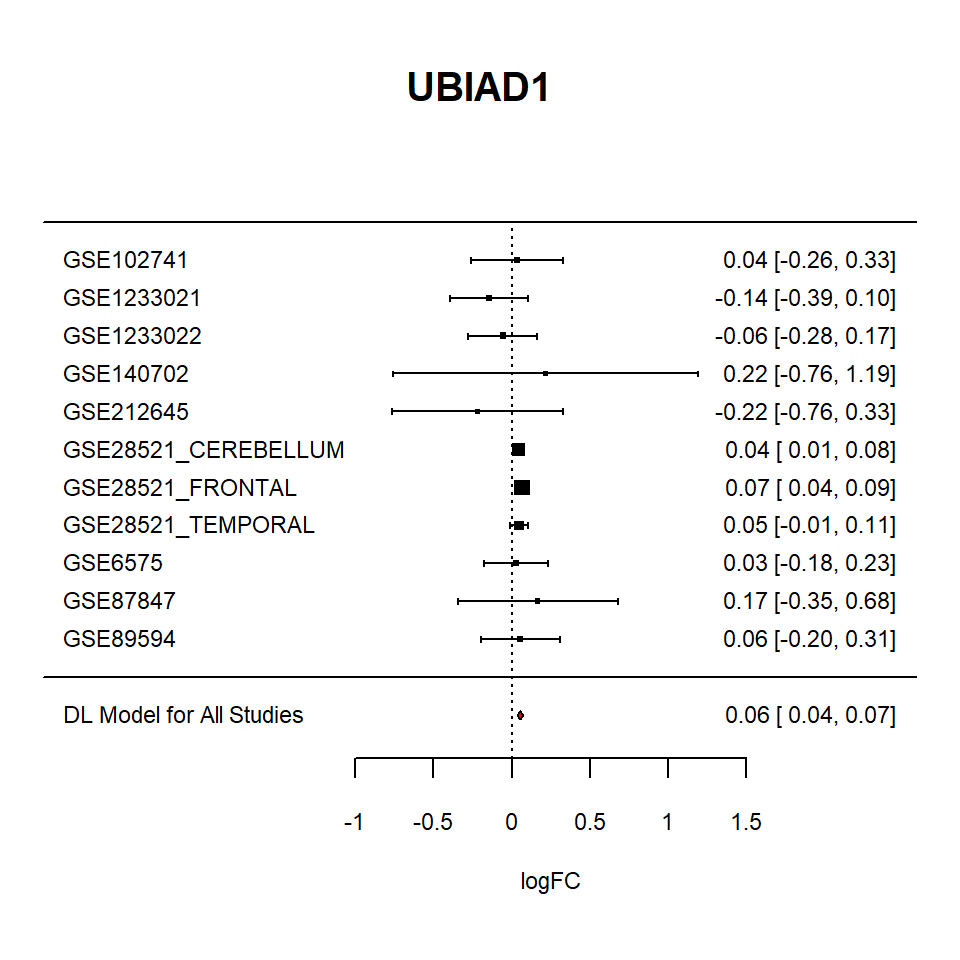

```r
knitr::include_graphics("plots/UBIAD1_FOREST.png")
```

**Funnel plot**

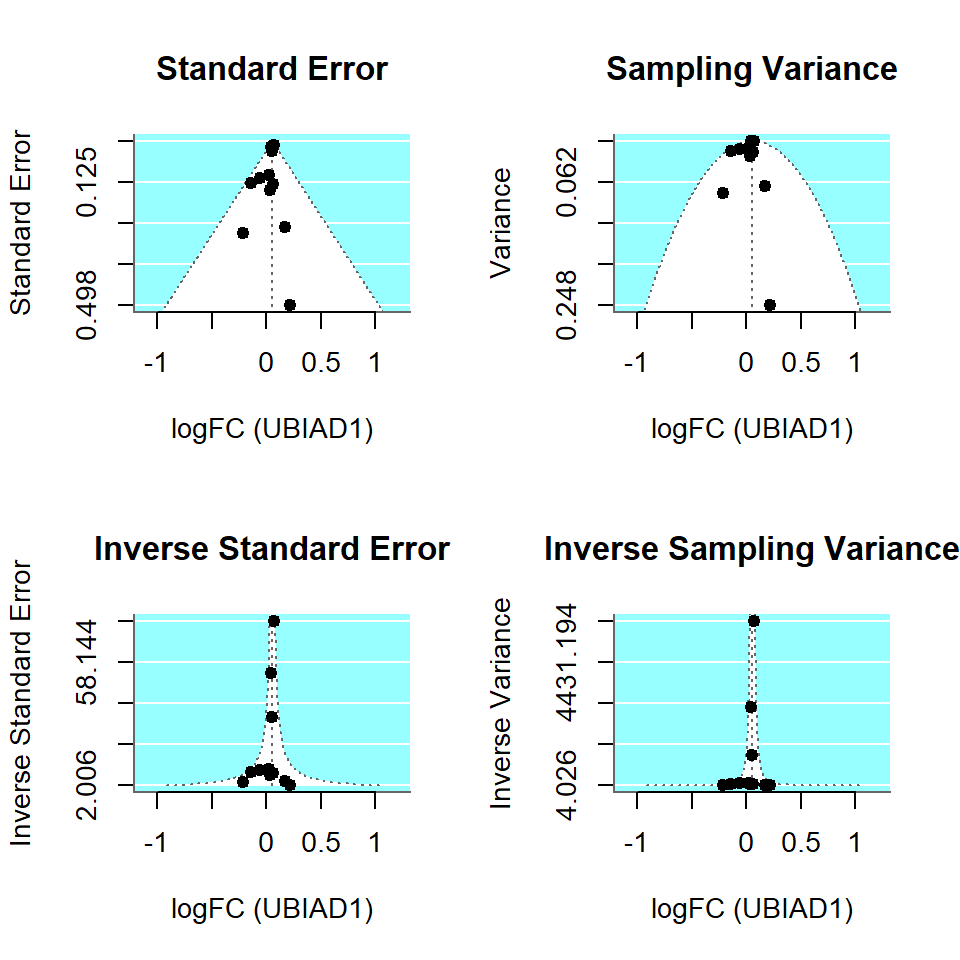

```r
knitr::include_graphics("plots/UBIAD1_FUNNEL.png")
```

**Incluence plot**

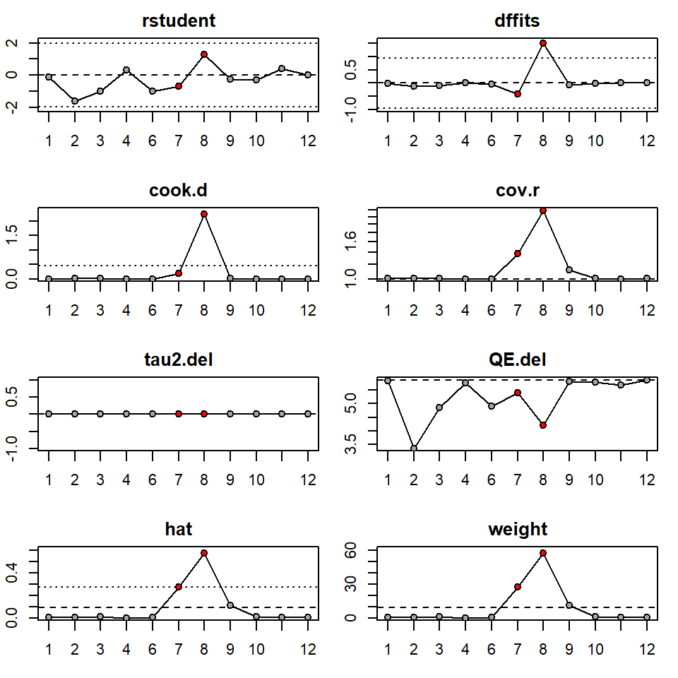

```r
knitr::include_graphics("plots/UBIAD1_INFLUENCE.png")
```

### LINC01362

**Statistics of LINC01362 meta-analisys**

```r
kable(sig.genes.df['LINC01362',1:11])
```

|  | lower_bound | logFC | upper_bound | pvalue | QE | QEp | SE | tau2 | I2 | H2 | p.adjust.fdr |
| --- | --- | --- | --- | --- | --- | --- | --- | --- | --- | --- | --- |
| LINC01362 | -0.235 | -0.17 | -0.105 | 0 | 0.859 | 0.354 | 0.033 | 0 | 0 | 1 | 0.002 |

[Gene information](https://www.genecards.org/cgi-bin/carddisp.pl?gene=LINC01362)

**Forest plot**

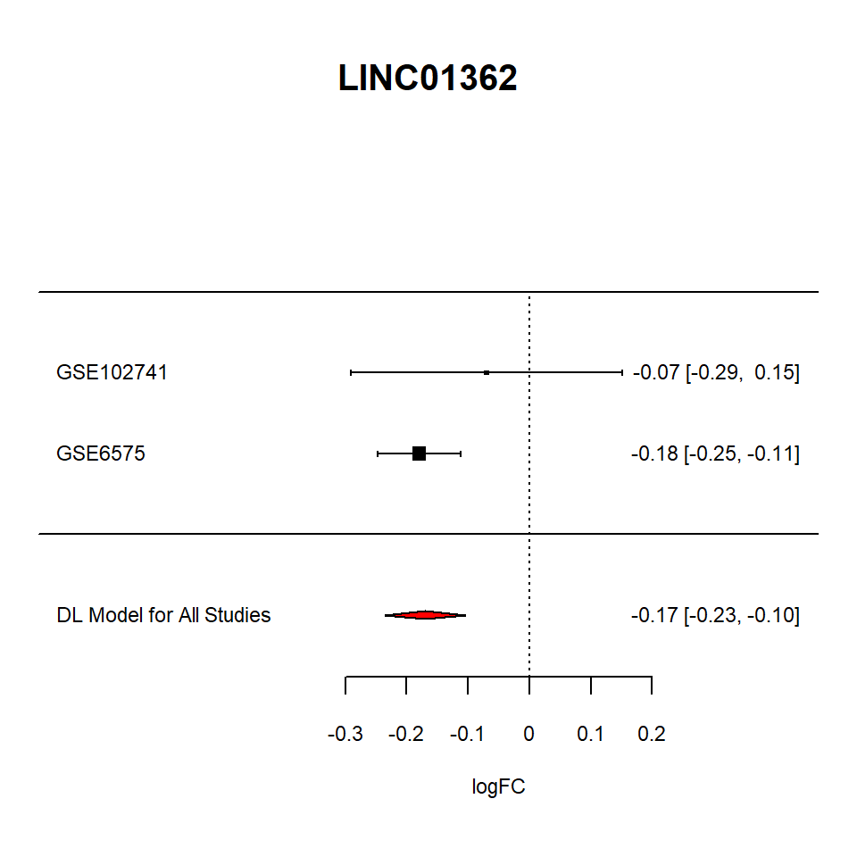

```r
knitr::include_graphics("plots/LINC01362_FOREST.png")
```

**Funnel plot**

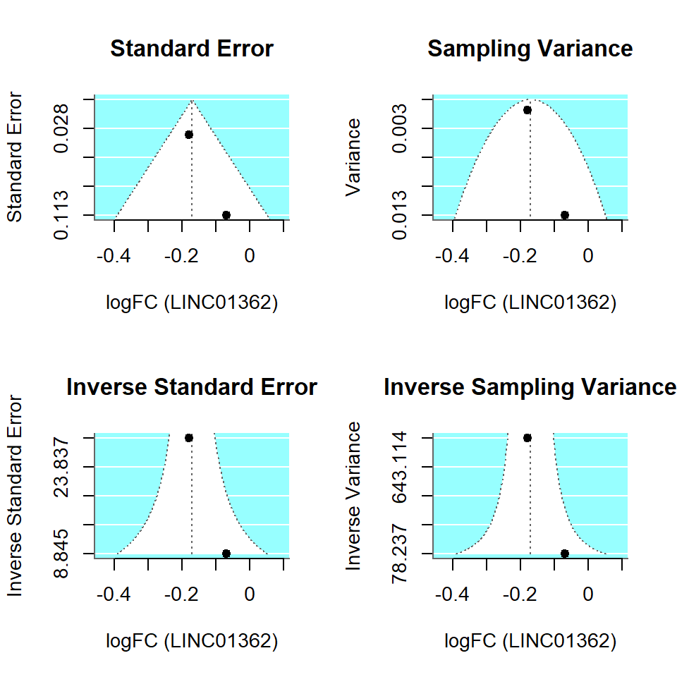

```r
knitr::include_graphics("plots/LINC01362_FUNNEL.png")
```

**Incluence plot**

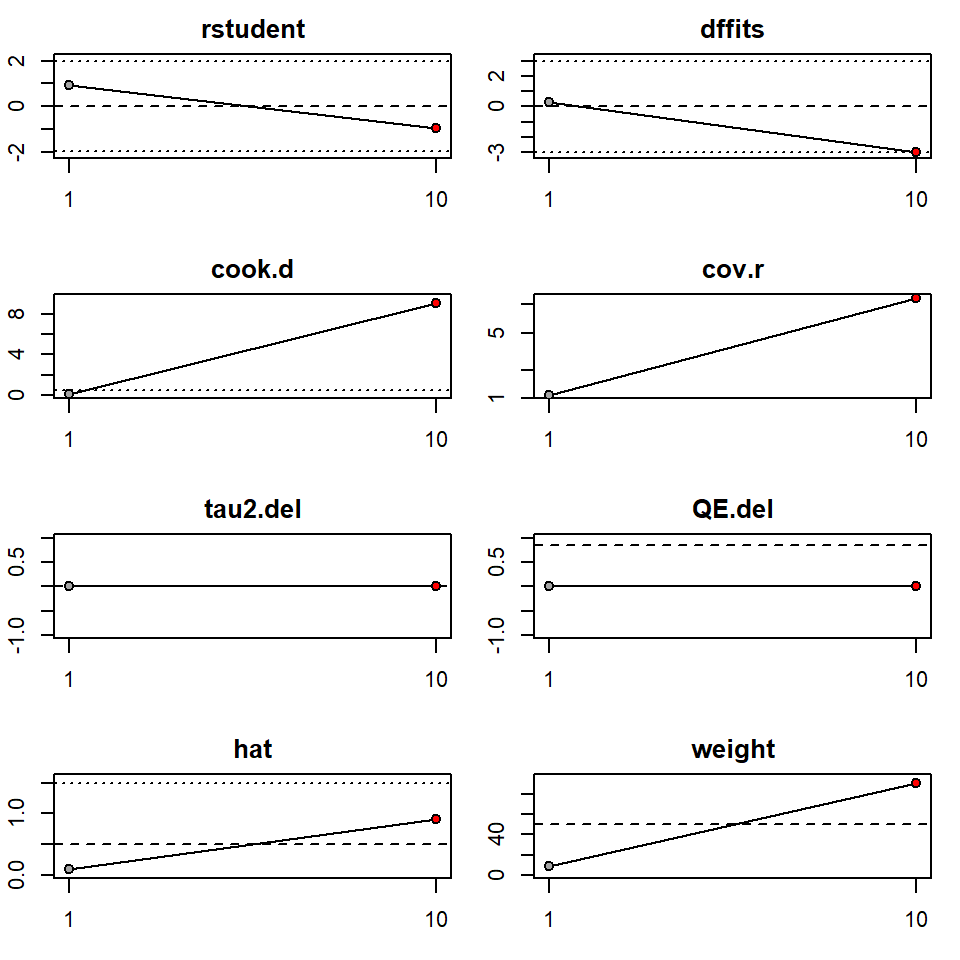

```r
knitr::include_graphics("plots/LINC01362_INFLUENCE.png")
```

### SLC29A1

**Statistics of SLC29A1 meta-analisys**

```r
kable(sig.genes.df['SLC29A1',1:11])
```

|  | lower_bound | logFC | upper_bound | pvalue | QE | QEp | SE | tau2 | I2 | H2 | p.adjust.fdr |
| --- | --- | --- | --- | --- | --- | --- | --- | --- | --- | --- | --- |
| SLC29A1 | -0.182 | -0.132 | -0.081 | 0 | 5.631 | 0.688 | 0.026 | 0 | 0 | 1 | 0.002 |

[Gene information](https://www.genecards.org/cgi-bin/carddisp.pl?gene=SLC29A1)

**Forest plot**

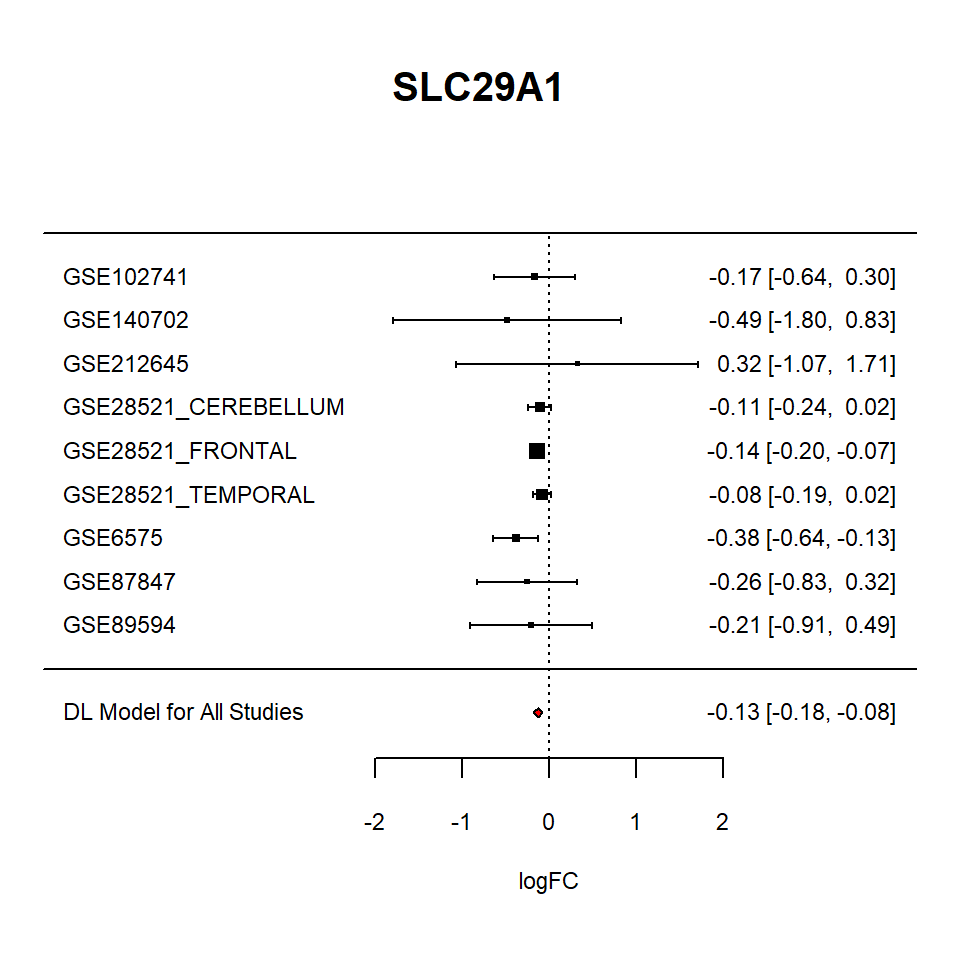

```r
knitr::include_graphics("plots/SLC29A1_FOREST.png")
```

**Funnel plot**

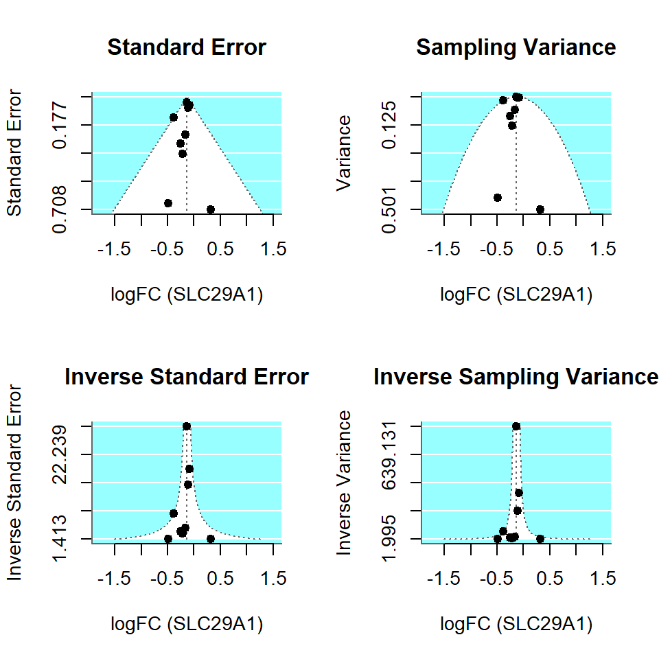

```r
knitr::include_graphics("plots/SLC29A1_FUNNEL.png")
```

**Incluence plot**

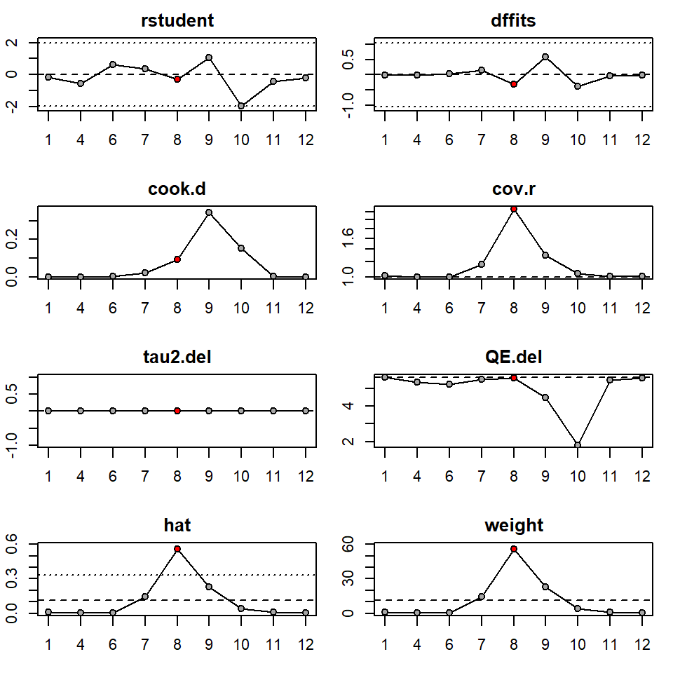

```r
knitr::include_graphics("plots/SLC29A1_INFLUENCE.png")
```

### COMMD2

**Statistics of COMMD2 meta-analisys**

```r
kable(sig.genes.df['COMMD2',1:11])
```

|  | lower_bound | logFC | upper_bound | pvalue | QE | QEp | SE | tau2 | I2 | H2 | p.adjust.fdr |
| --- | --- | --- | --- | --- | --- | --- | --- | --- | --- | --- | --- |
| COMMD2 | 0.077 | 0.127 | 0.177 | 0 | 10.095 | 0.343 | 0.026 | 0.001 | 10.849 | 1.122 | 0.004 |

[Gene information](https://www.genecards.org/cgi-bin/carddisp.pl?gene=COMMD2)

**Forest plot**

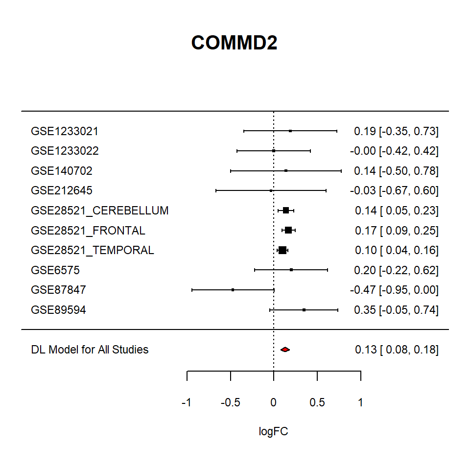

```r
knitr::include_graphics("plots/COMMD2_FOREST.png")
```

**Funnel plot**

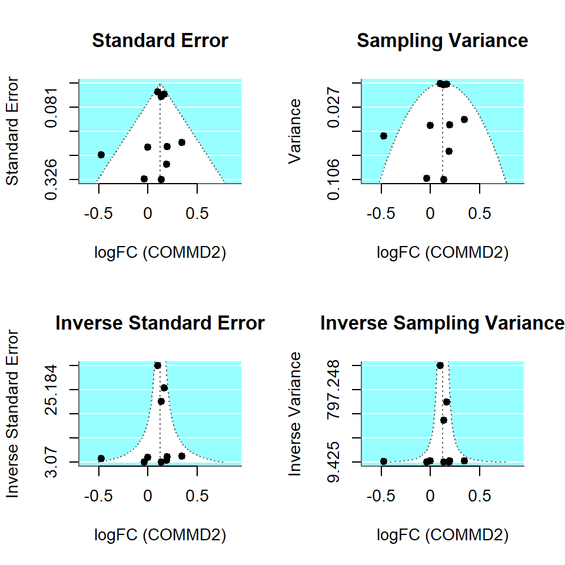

```r
knitr::include_graphics("plots/COMMD2_FUNNEL.png")
```

**Incluence plot**

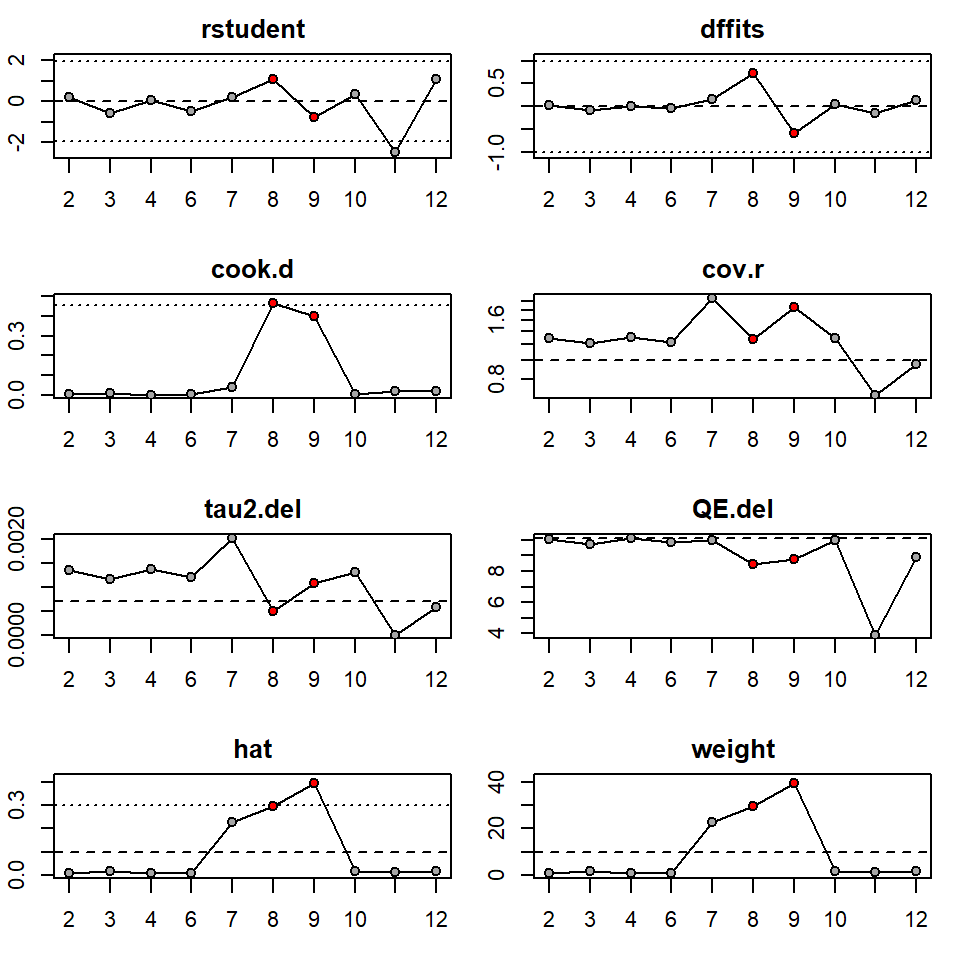

```r
knitr::include_graphics("plots/COMMD2_INFLUENCE.png")
```

### ATP6V0D2

**Statistics of ATP6V0D2 meta-analisys**

```r
kable(sig.genes.df['ATP6V0D2',1:11])
```

|  | lower_bound | logFC | upper_bound | pvalue | QE | QEp | SE | tau2 | I2 | H2 | p.adjust.fdr |
| --- | --- | --- | --- | --- | --- | --- | --- | --- | --- | --- | --- |
| ATP6V0D2 | -0.517 | -0.368 | -0.219 | 0 | 3.242 | 0.518 | 0.076 | 0 | 0 | 1 | 0.006 |

[Gene information](https://www.genecards.org/cgi-bin/carddisp.pl?gene=ATP6V0D2)

**Forest plot**

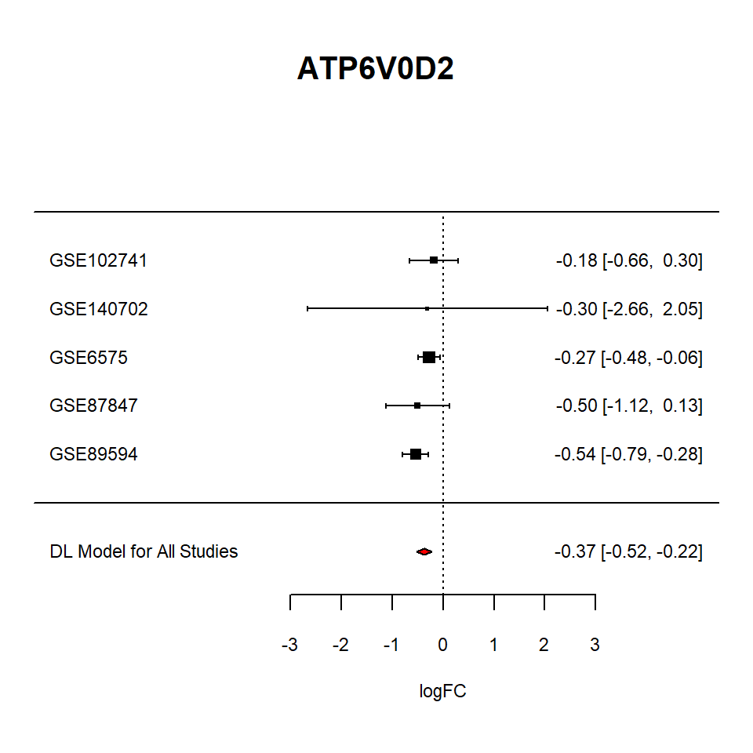

```r
knitr::include_graphics("plots/ATP6V0D2_FOREST.png")
```

**Funnel plot**

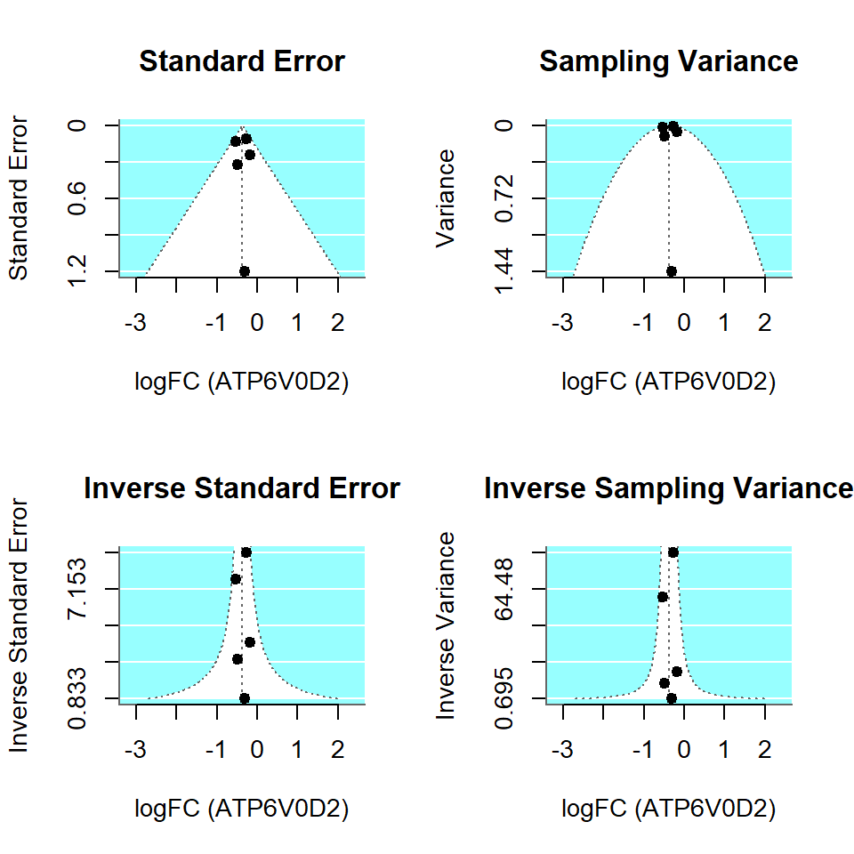

```r
knitr::include_graphics("plots/ATP6V0D2_FUNNEL.png")
```

**Incluence plot**

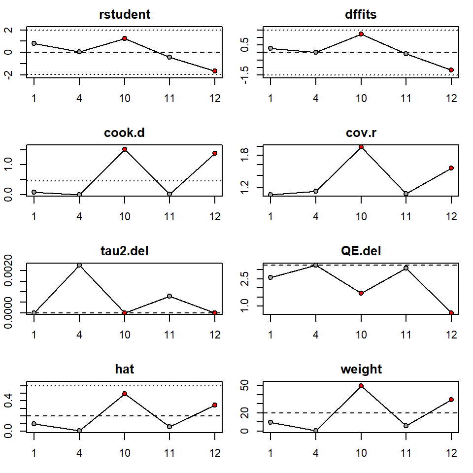

```r
knitr::include_graphics("plots/ATP6V0D2_INFLUENCE.png")
```

### LOC91561

**Statistics of LOC91561 meta-analisys**

```r
kable(sig.genes.df['LOC91561',1:11])
```

|  | lower_bound | logFC | upper_bound | pvalue | QE | QEp | SE | tau2 | I2 | H2 | p.adjust.fdr |
| --- | --- | --- | --- | --- | --- | --- | --- | --- | --- | --- | --- |
| LOC91561 | 0.024 | 0.041 | 0.058 | 0 | 1.083 | 0.781 | 0.009 | 0 | 0 | 1 | 0.007 |

[Gene information](https://www.genecards.org/cgi-bin/carddisp.pl?gene=LOC91561)

**Forest plot**

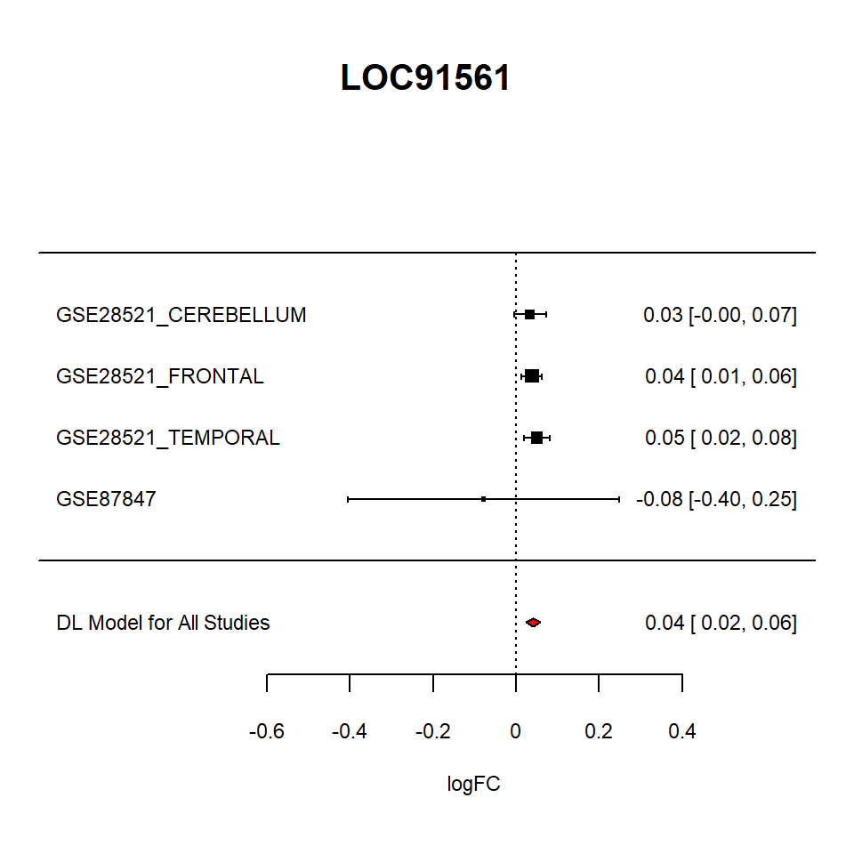

```r
knitr::include_graphics("plots/LOC91561_FOREST.png")
```

**Funnel plot**

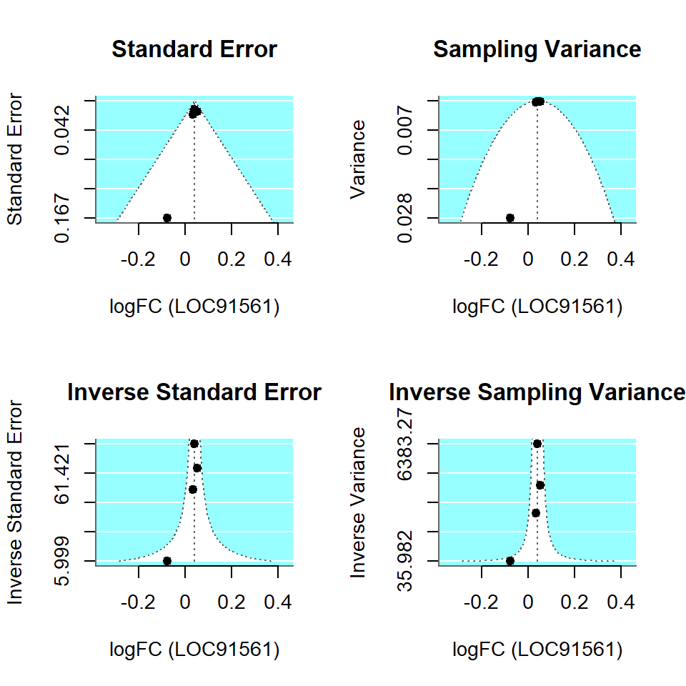

```r
knitr::include_graphics("plots/LOC91561_FUNNEL.png")
```

**Incluence plot**

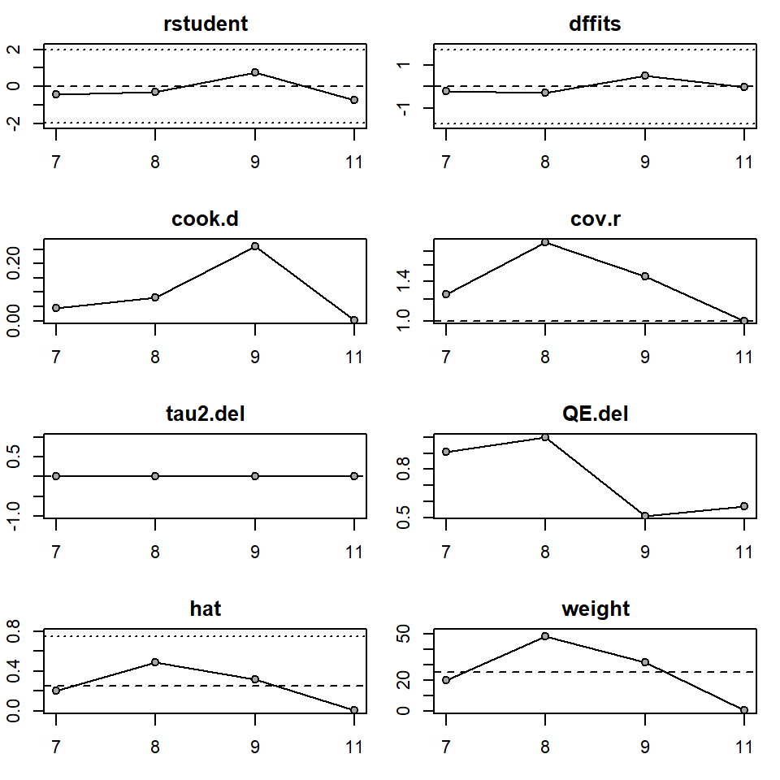

```r
knitr::include_graphics("plots/LOC91561_INFLUENCE.png")
```

### SECTM1

**Statistics of SECTM1 meta-analisys**

```r
kable(sig.genes.df['SECTM1',1:11])
```

|  | lower_bound | logFC | upper_bound | pvalue | QE | QEp | SE | tau2 | I2 | H2 | p.adjust.fdr |
| --- | --- | --- | --- | --- | --- | --- | --- | --- | --- | --- | --- |
| SECTM1 | -0.418 | -0.296 | -0.174 | 0 | 3.217 | 0.864 | 0.062 | 0 | 0 | 1 | 0.007 |

[Gene information](https://www.genecards.org/cgi-bin/carddisp.pl?gene=SECTM1)

**Forest plot**

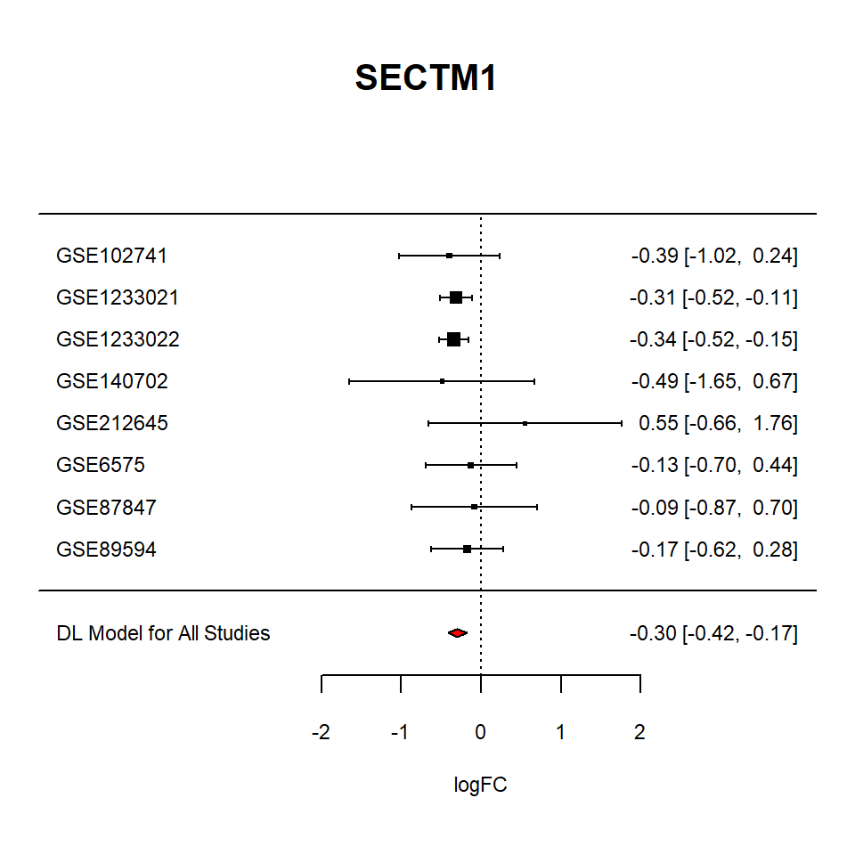

```r
knitr::include_graphics("plots/SECTM1_FOREST.png")
```

**Funnel plot**

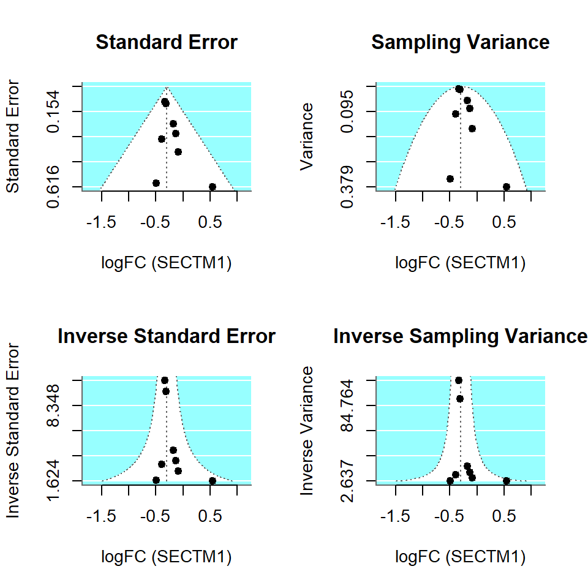

```r
knitr::include_graphics("plots/SECTM1_FUNNEL.png")
```

**Incluence plot**

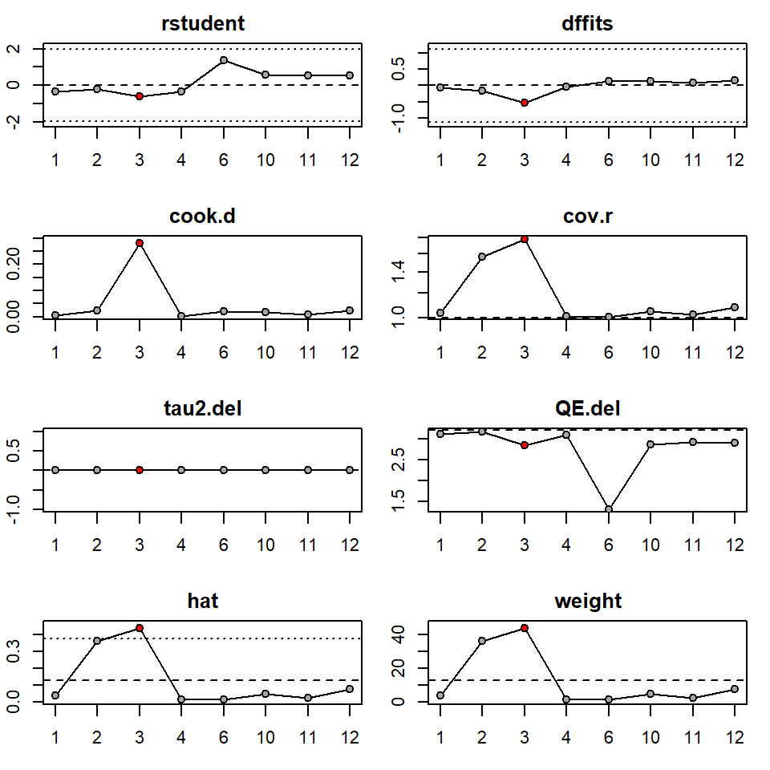

```r
knitr::include_graphics("plots/SECTM1_INFLUENCE.png")
```

### TMED1

**Statistics of TMED1 meta-analisys**

```r
kable(sig.genes.df['TMED1',1:11])
```

|  | lower_bound | logFC | upper_bound | pvalue | QE | QEp | SE | tau2 | I2 | H2 | p.adjust.fdr |
| --- | --- | --- | --- | --- | --- | --- | --- | --- | --- | --- | --- |
| TMED1 | 0.032 | 0.056 | 0.08 | 0 | 2.864 | 0.969 | 0.012 | 0 | 0 | 1 | 0.01 |

[Gene information](https://www.genecards.org/cgi-bin/carddisp.pl?gene=TMED1)

**Forest plot**

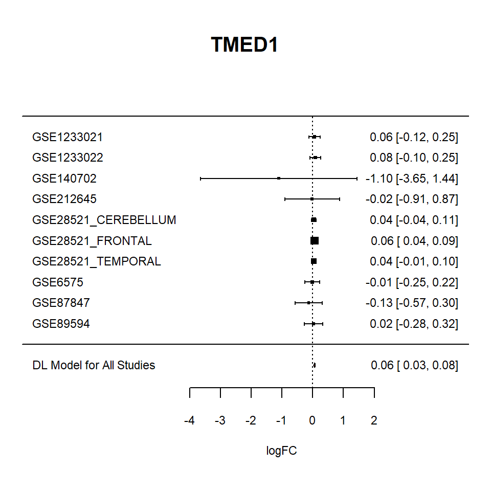

```r
knitr::include_graphics("plots/TMED1_FOREST.png")
```

**Funnel plot**

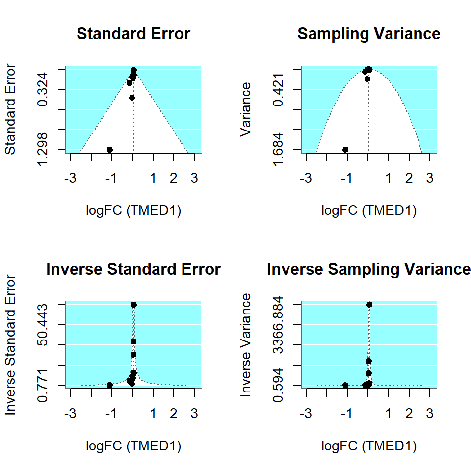

```r
knitr::include_graphics("plots/TMED1_FUNNEL.png")
```

**Incluence plot**

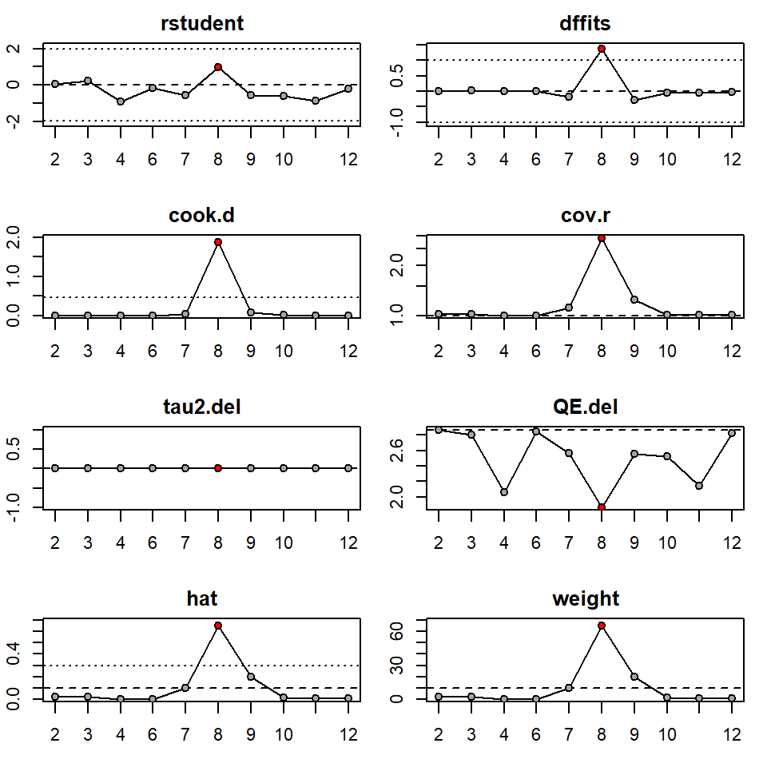

```r
knitr::include_graphics("plots/TMED1_INFLUENCE.png")
```

### LOC400566

**Statistics of LOC400566 meta-analisys**

```r
kable(sig.genes.df['LOC400566',1:11])
```

|  | lower_bound | logFC | upper_bound | pvalue | QE | QEp | SE | tau2 | I2 | H2 | p.adjust.fdr |
| --- | --- | --- | --- | --- | --- | --- | --- | --- | --- | --- | --- |
| LOC400566 | -0.183 | -0.128 | -0.073 | 0 | 0.974 | 0.614 | 0.028 | 0 | 0 | 1 | 0.011 |

[Gene information](https://www.genecards.org/cgi-bin/carddisp.pl?gene=LOC400566)

**Forest plot**

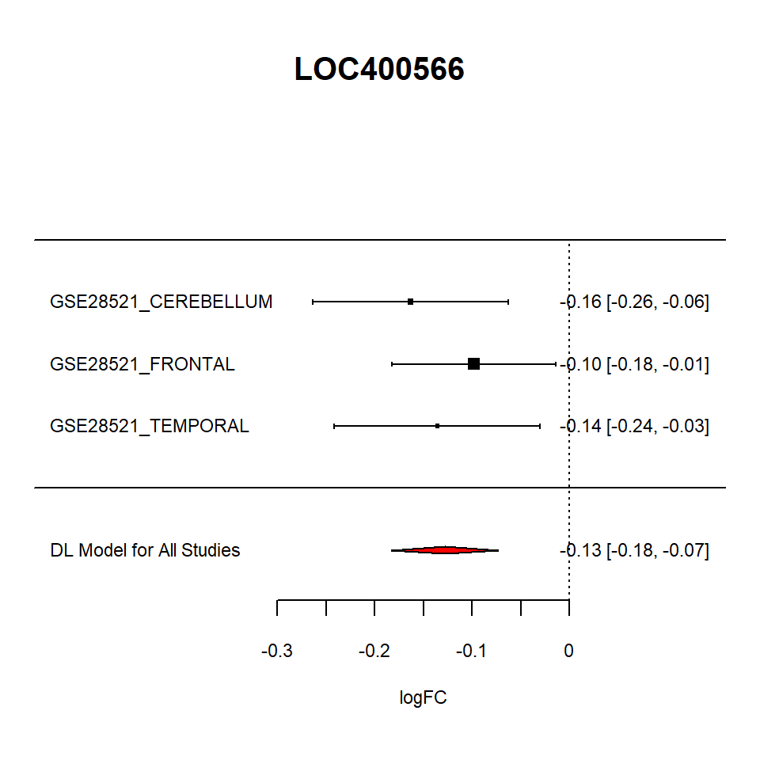

```r
knitr::include_graphics("plots/LOC400566_FOREST.png")
```

**Funnel plot**

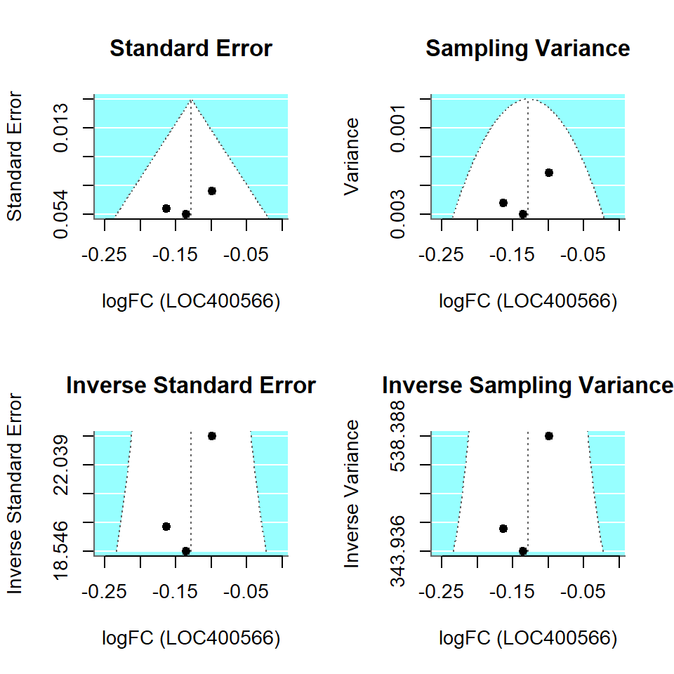

```r
knitr::include_graphics("plots/LOC400566_FUNNEL.png")
```

**Incluence plot**

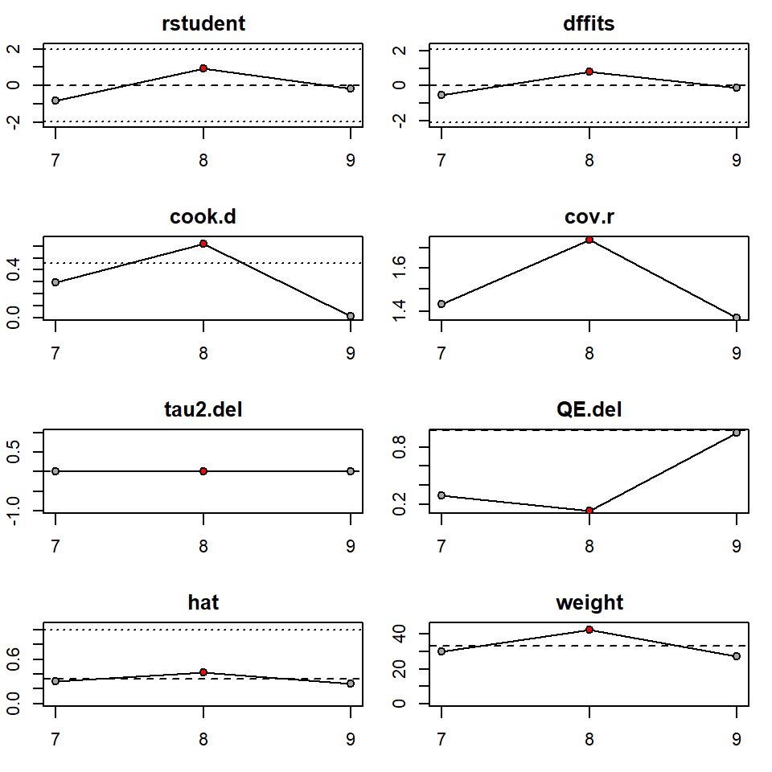

```r
knitr::include_graphics("plots/LOC400566_INFLUENCE.png")
```